# Rockfish Historical Harvest Estimates

### P(pelagic)

We model the percentage of pelagic rockfish in the harvest because we have the information for charter anglers (via logbooks) starting in 1998. Other than looking at the model estimates you can use Figure 25 to compare the two data streams for pelagic rockfish harvest. In general they are in agreement with major exceptions in Price William Sound inside, Prince William Sound outside (early in the time series) and South Southeast inside.

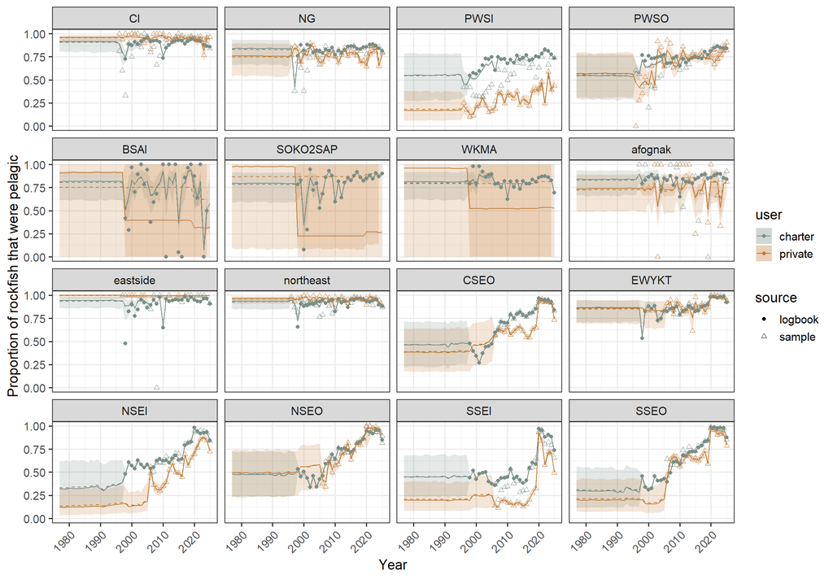

**Figure 32.**- Annual estimates of the percent of the sport harvest that was pelagic rockfish for 16 commerical fishing manamgent areas, 1996-2023.

### P(black|pelagic)

Note that in Southeast Alaska we only have composition data starting in 2006. Tania dug up old SE data, but it did not provide any useful data for species apportionment. For the most part, P(black|pelagic) is relatively constant across areas, with the exception of Cook Inlet and NSEI in Southeast AK. It may be worth discussing whether the shifts in those areas is a result of improved or changing species identification rather than actual shift in the species composition of the catch.

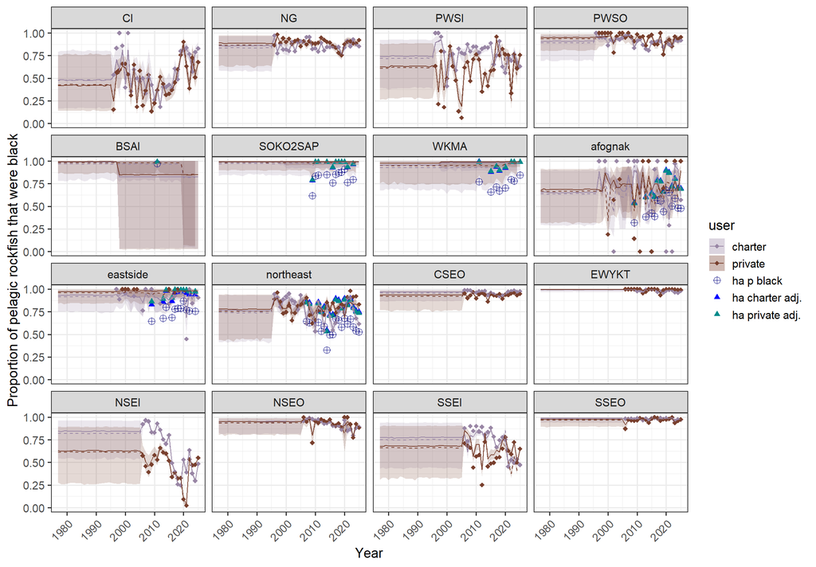

### P(yelloweye|non-pelagic / yelloweye|DSR)

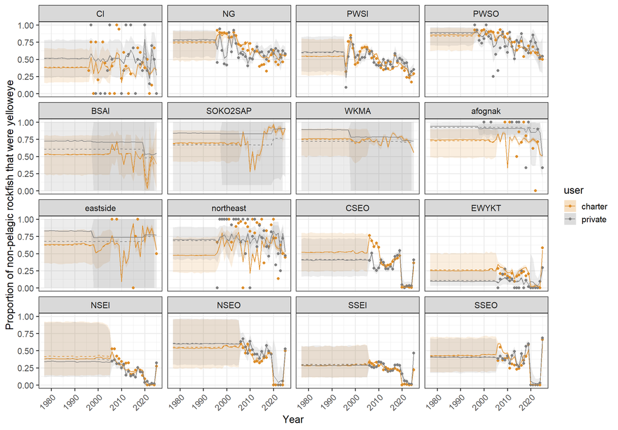

**Figure 34.**- Annual estimates of the percent of the sport harvest of non-pelagic rockfish that were yelloweye rockfish for 16 commerical fishing manamgent areas, 1996-2023. Note that P(yelloweye) is the the proportion relative to non-pelagics for Central and Kodiak areas but is relative to DSR for Southeast areas.

### P(DSR|non-pelagic)

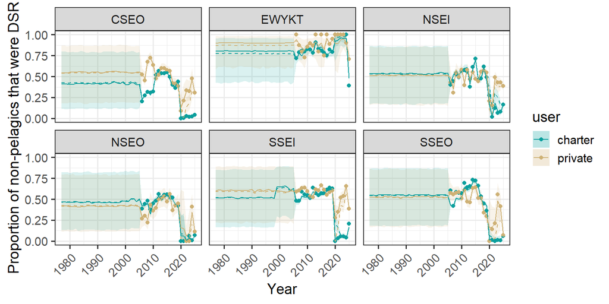

**Figure 35.**- Annual estimates of the percent of the sport harvest of non-pelagic rockfish that were DSR rockfish for 6 Southeast commerical fishing manamgent areas, 1996-2023.

### P(slope|non-pelagic)

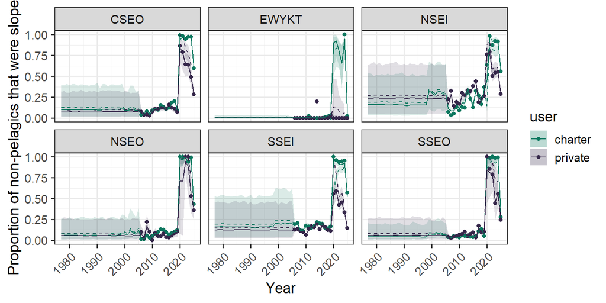

**Figure 36.**- Annual estimates of the percent of the sport harvest of non-pelagic rockfish that were slope rockfish for 6 southeast commerical fishing manamgent areas, 1996-2023. Note that P(yelloweye) is the the proportion relative to non-pelagics for Central and Kodiak areas but is relative to DSR for Southeast areas.

### Weight Fits

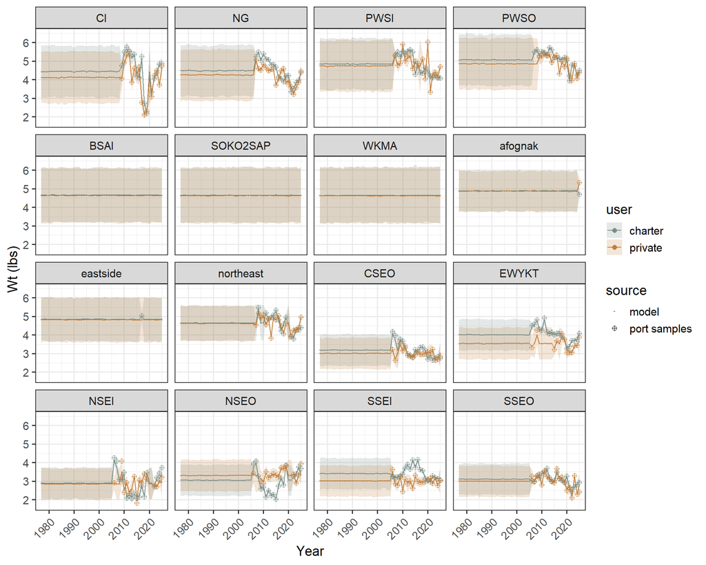

**Figure 37.**- Mean weights of black rockfish used to estimate biomass from harvest and release mortality estimates in numbers of fish.

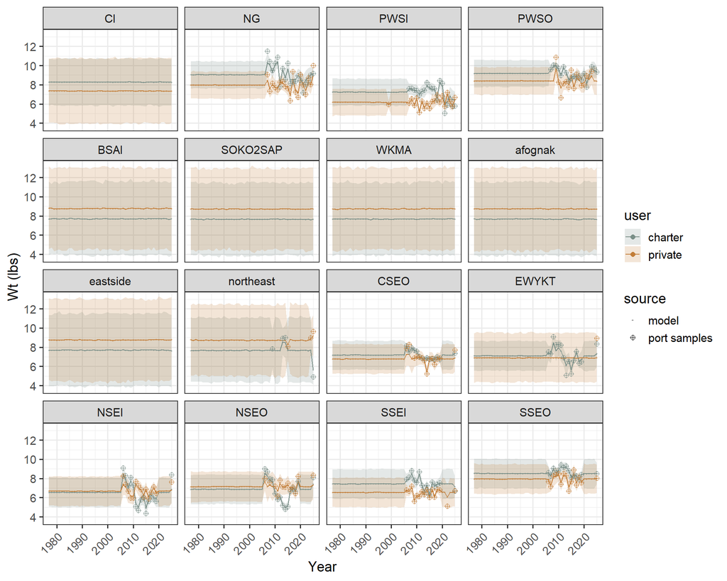

**Figure 38.**- Mean weights of yelloweye rockfish used to estimate biomass from harvest and release mortality estimates in numbers of fish.

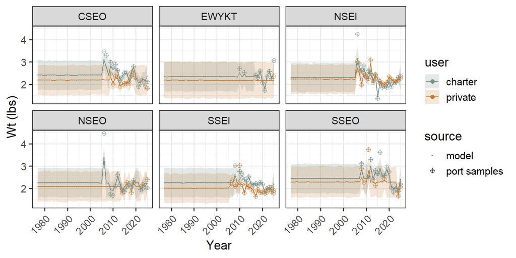

**Figure 39.**- Mean weights of non-black, pelagic rockfish used to estimate biomass from harvest and release mortality estimates in numbers of fish.

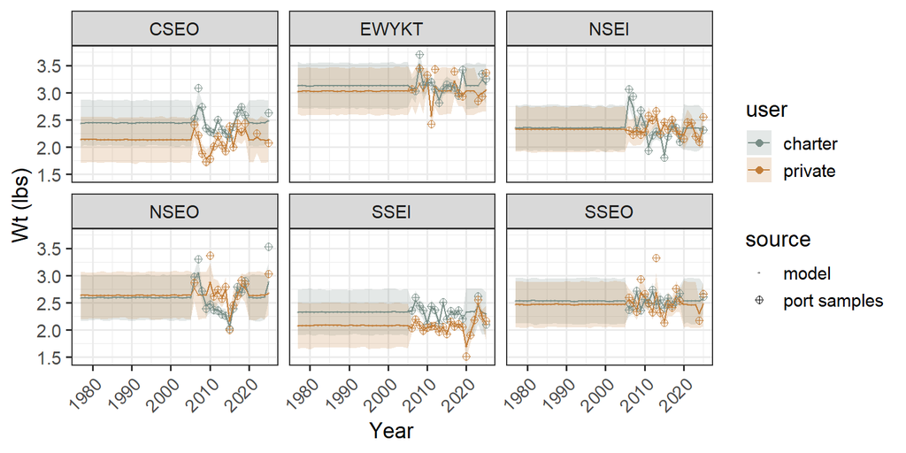

**Figure 40.**- Mean weights of non-yelloweye, demersal shelf rockfish used to estimate biomass from harvest and release mortality estimates in numbers of fish.

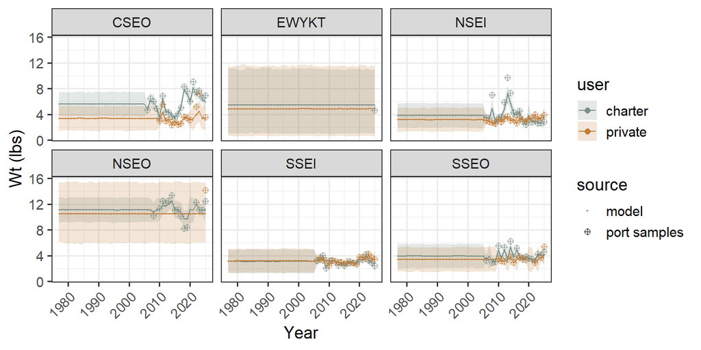

**Figure 41.**- Mean weights of slope rockfish used to estimate biomass from harvest and release mortality estimates in numbers of fish.

### Summary of unconverged parameters:

The proportion of unconverged species composition proportional estimates that are near the bounds of 0 or 1 is 0.8813559

The proportion of unconverged true parameters (defined as Rhat > 1.01) that are also in excess of an Rhat of 1.1 is 0.06 while 0.94 are less than 1.1.

**Table Xa.** Species proportion derived quantities that are not with 0.05 of the 0 and 1 bounds and are not converged relative to an Rhat of 1.01.

| variable | area_n | year | user | mean | median | lower | upper | Rhat | sd | skew | area |
| --- | --- | --- | --- | --- | --- | --- | --- | --- | --- | --- | --- |
| p_slope | 13 | 44 | 1 | 0.448 | 0.445 | 0.302 | 0.608 | 1.035 | 0.077 | 0.039 | NSEI |
| p_pelagic | 13 | 45 | 1 | 0.941 | 0.941 | 0.938 | 0.944 | 1.010 | 0.002 | 0.000 | NSEI |
| p_dsr | 13 | 45 | 2 | 0.156 | 0.153 | 0.094 | 0.232 | 1.016 | 0.036 | 0.084 | NSEI |
| p_pelagic | 13 | 46 | 1 | 0.926 | 0.927 | 0.922 | 0.931 | 1.021 | 0.002 | -0.410 | NSEI |
| p_dsr | 13 | 46 | 1 | 0.183 | 0.182 | 0.118 | 0.255 | 1.094 | 0.035 | 0.029 | NSEI |
| p_dsr | 13 | 47 | 1 | 0.084 | 0.080 | 0.036 | 0.149 | 1.084 | 0.029 | 0.136 | NSEI |
| p_dsr | 13 | 48 | 1 | 0.068 | 0.066 | 0.035 | 0.110 | 1.116 | 0.019 | 0.103 | NSEI |

| variable | area_n | year/species | mean | median | lower | upper | Rhat | sd | skew | year | area |
| --- | --- | --- | --- | --- | --- | --- | --- | --- | --- | --- | --- |
| tau_beta5_pH | 1 | 4 | 1.820 | 0.153 | 0.042 | 17.054 | 1.015 | 7.265 | 0.229 |  | CI |
| beta4_pH | 1 | 4 | 0.654 | 0.587 | 0.233 | 1.486 | 1.010 | 0.327 | 0.205 |  | CI |
| beta0_H | 10 |  | 9.621 | 9.074 | -5.424 | 25.079 | 1.078 | 19.599 | 0.028 |  | northeast |
| beta5_pH | 11 | 4 | -3.636 | -3.631 | -3.931 | -3.362 | 1.044 | 0.144 | -0.035 |  | CSEO |
| beta4_dsr | 11 |  | 3.020 | 3.020 | 2.595 | 3.442 | 1.026 | 0.215 | 0.000 |  | CSEO |
| beta5_dsr | 11 |  | -3.981 | -3.977 | -4.275 | -3.717 | 1.047 | 0.142 | -0.028 |  | CSEO |
| beta0_H | 11 |  | 11.026 | 11.002 | -4.521 | 27.889 | 1.011 | 10.120 | 0.002 |  | CSEO |
| beta5_dsr | 12 |  | 2.838 | 2.783 | 1.776 | 4.217 | 1.035 | 0.628 | 0.088 |  | EWYKT |
| beta0_H | 12 |  | 9.092 | 9.224 | -7.352 | 25.242 | 1.017 | 10.607 | -0.012 |  | EWYKT |
| beta4_pH | 13 | 4 | 2.578 | 0.090 | 0.015 | 14.157 | 3.005 | 4.234 | 0.588 |  | NSEI |
| beta4_pH | 13 | 5 | 12.551 | 11.814 | 4.592 | 23.775 | 1.684 | 5.602 | 0.132 |  | NSEI |
| beta5_pH | 13 | 4 | -0.370 | -0.511 | -0.805 | 0.119 | 5.830 | 0.326 | 0.432 |  | NSEI |
| beta5_pH | 13 | 5 | -0.070 | -0.063 | -0.139 | -0.029 | 1.840 | 0.041 | -0.172 |  | NSEI |
| beta4_dsr | 13 |  | 1.651 | 1.649 | 1.301 | 2.023 | 1.233 | 0.183 | 0.011 |  | NSEI |
| beta5_dsr | 13 |  | -2.340 | -2.337 | -2.684 | -2.020 | 1.336 | 0.170 | -0.018 |  | NSEI |
| beta_H | 13 | 1 | 9.700 | 9.782 | 7.357 | 11.523 | 1.025 | 1.032 | -0.079 |  | NSEI |
| beta0_H | 13 |  | 10.122 | 10.647 | -8.343 | 27.241 | 1.053 | 13.730 | -0.038 |  | NSEI |
| beta_H | 13 | 1 | 9.700 | 9.782 | 7.357 | 11.523 | 1.025 | 1.032 | -0.079 |  | NSEI |
| beta5_pH | 14 | 2 | -5.144 | -5.122 | -5.681 | -4.668 | 1.034 | 0.263 | -0.084 |  | NSEO |
| beta5_yellow | 14 |  | -4.812 | -4.793 | -5.354 | -4.333 | 1.035 | 0.264 | -0.072 |  | NSEO |
| beta0_H | 14 |  | 10.145 | 10.084 | -5.993 | 26.151 | 1.014 | 10.918 | 0.006 |  | NSEO |
| beta5_pH | 15 | 4 | -3.422 | -3.417 | -3.684 | -3.176 | 1.018 | 0.129 | -0.039 |  | SSEI |
| beta5_pH | 15 | 5 | 0.286 | 0.283 | 0.144 | 0.439 | 1.016 | 0.079 | 0.038 |  | SSEI |
| beta5_dsr | 15 |  | -3.044 | -3.041 | -3.327 | -2.787 | 1.018 | 0.135 | -0.022 |  | SSEI |
| beta5_pH | 16 | 5 | -0.159 | -0.206 | -0.333 | 0.217 | 1.033 | 0.153 | 0.306 |  | SSEO |
| beta4_dsr | 16 |  | 3.226 | 3.201 | 2.303 | 4.334 | 1.014 | 0.511 | 0.049 |  | SSEO |
| beta5_dsr | 16 |  | -4.589 | -4.556 | -5.558 | -3.851 | 1.026 | 0.433 | -0.076 |  | SSEO |
| beta5_slope | 16 |  | 3.779 | 3.754 | 2.908 | 4.823 | 1.014 | 0.503 | 0.050 |  | SSEO |
| beta0_H | 16 |  | 9.660 | 10.312 | -11.639 | 27.542 | 1.025 | 17.022 | -0.038 |  | SSEO |
| beta4_pH | 2 | 4 | 0.777 | 0.596 | 0.135 | 2.638 | 1.011 | 0.711 | 0.255 |  | NG |

[output cut: 83 more lines]

**Table Xc.** Summary statistics describing the characteristics of the derived harvest and release estimates that are not converged relative to an Rhat of 1.01.

| Statistic | non.BSAI.SOKO.Harv | BSAI.SOKO.Harv | non.BSAI.SOKO.Rel | BSAI.SOKO.Rel |
| --- | --- | --- | --- | --- |
| n unconverged at Rhat = 1.01 | 190.00 | 42.00 | 174.00 | 46.00 |
| Prop. of total | 0.82 | 0.18 | 0.79 | 0.21 |
| Prop. median less than 1 | 0.16 | 0.00 | 0.20 | 0.13 |
| Prop. median less than 10 | 0.27 | 0.14 | 0.28 | 0.41 |
| Prop. median less than 50 | 0.42 | 0.24 | 0.36 | 0.63 |
| Median of the median values | 262.27 | 226.27 | 243.98 | 16.13 |
| Mean of the median values | 2,550.86 | 1,203.89 | 1,149.68 | 694.95 |
| Mean skew of posteriors | 0.11 | 0.11 | 0.15 | 0.11 |

**Table Xd.** Summary statistics describing the characteristics of the derived harvest and release estimates that are not converged relative to an Rhat of 1.1.

| Statistic | non.BSAI.SOKO.Harv | BSAI.SOKO.Harv | non.BSAI.SOKO.Rel | BSAI.SOKO.Rel |
| --- | --- | --- | --- | --- |
| n unconverged at Rhat = 1.1 | 1.00 | 0 | 12.00 | 2.00 |
| Prop. of total | 1.00 | 0 | 0.86 | 0.14 |
| Prop. median less than 1 | 0.00 |  | 0.42 | 0.00 |
| Prop. median less than 10 | 0.00 |  | 0.50 | 0.00 |
| Prop. median less than 50 | 0.00 |  | 0.50 | 0.50 |
| Median of the median values | 270.29 |  | 30.04 | 65.59 |
| Mean of the median values | 270.29 |  | 140.79 | 65.59 |
| Mean skew of posteriors | 0.03 |  | 0.14 | 0.18 |

**Table Xe.** All parameters and derived quantities that are not converged relative to an Rhat of 1.1.

[output not shown]

[output cut: 2858 more lines]

### Parameter estimates:

Summary Table of Parameter Estimates

[output not shown]